# y_05_pm2.5_lag_analysis

Yanelli Nunez

10/4/2021

Objective:

- Ran distributed lag models and two different lag constrains (3 and 4 degrees of freedom). The exposure-response function will be set as linear because the models for the averaged exposures indicate no deviation from linearity in the dose-response.
- To determined df on the lag constrain I used AIC to chose the model with the best fitness
- I ran the model with the best AIC twice–with and without parish SES adjustment

## 1. View data

```r
summary(data_lags)
```

```
##        nr           lobnr             ck            diagtype
##  Min.   :   2   Min.   :0.000   Min.   :0.0000   Min.   :1
##  1st Qu.:1215   1st Qu.:1.000   1st Qu.:0.0000   1st Qu.:1
##  Median :2404   Median :2.000   Median :0.0000   Median :1
##  Mean   :2382   Mean   :2.484   Mean   :0.1723   Mean   :1
##  3rd Qu.:3601   3rd Qu.:4.000   3rd Qu.:0.0000   3rd Qu.:1
##  Max.   :4608   Max.   :5.000   Max.   :1.0000   Max.   :1
##
##     diagdat                 ID         aegtesocial        bdate
##  Min.   :1989-09-04   Min.   :    9   Min.   :1.000   Min.   :1901-02-06
##  1st Qu.:1997-08-15   1st Qu.: 9700   1st Qu.:3.000   1st Qu.:1927-06-02
##  Median :2004-01-28   Median :19211   Median :5.000   Median :1936-11-01
##  Mean   :2003-04-22   Mean   :19022   Mean   :5.256   Mean   :1937-06-06
##  3rd Qu.:2009-03-14   3rd Qu.:28765   3rd Qu.:9.000   3rd Qu.:1946-03-02
##  Max.   :2013-12-30   Max.   :36806   Max.   :9.000   Max.   :1987-06-01
##                                       NA's   :26257
##  civst        civstdat5             d_inddto             d_uddto
##  1: 21901   Min.   :1900-07-01   Min.   :1989-09-04   Min.   :1989-09-07
##  2: 44308   1st Qu.:1960-09-29   1st Qu.:1997-08-15   1st Qu.:1998-01-01
##  3: 28061   Median :1973-02-11   Median :2004-02-07   Median :2004-08-03
##  4:148445   Mean   :1974-09-02   Mean   :2003-04-29   Mean   :2003-10-27
##             3rd Qu.:1989-06-23   3rd Qu.:2009-03-27   3rd Qu.:2009-11-24
##             Max.   :2013-08-30   Max.   :2013-12-30   Max.   :2014-11-01
##             NA's   :21901
##     daars1             daars2              diag                diy
##  Length:242715      Length:242715      Length:242715      Min.   :1989
##  Class :character   Class :character   Class :character   1st Qu.:1997
##  Mode  :character   Mode  :character   Mode  :character   Median :2004
##                                                           Mean   :2003
##                                                           3rd Qu.:2009
##                                                           Max.   :2013
##
##  family_SES    geokode           mynkod        pattype          postnr
##  1:24431    Min.   : 1.000   Min.   :   0   Min.   :1.000   Min.   :1050
##  2:29766    1st Qu.: 2.000   1st Qu.:7104   1st Qu.:1.000   1st Qu.:3070
##  3:46343    Median : 4.000   Median :7746   Median :2.000   Median :5270
##  4:69553    Mean   : 6.822   Mean   :7117   Mean   :1.598   Mean   :5580
##  5:46717    3rd Qu.: 7.000   3rd Qu.:8383   3rd Qu.:2.000   3rd Qu.:7850
##  9:25905    Max.   :62.000   Max.   :9999   Max.   :3.000   Max.   :9990
##                                                             NA's   :418
```

[output cut: 17 more lines]

```
##  Min.   :1901   Min.   : 0   Min.   : 6.087   Min.   :  0.16   Min.   :7001
##  1st Qu.:1927   1st Qu.: 2   1st Qu.:10.912   1st Qu.:  4.56   1st Qu.:7345
##  Median :1936   Median : 5   Median :12.501   Median : 12.02   Median :7934
##  Mean   :1937   Mean   : 5   Mean   :13.191   Mean   : 17.19   Mean   :8029
##  3rd Qu.:1946   3rd Qu.: 8   3rd Qu.:15.214   3rd Qu.: 23.36   3rd Qu.:8775
##  Max.   :1987   Max.   :10   Max.   :32.699   Max.   :156.57   Max.   :9312
##                                               NA's   :5621     NA's   :165
##    parish_ses
##  Min.   :40.00
##  1st Qu.:60.00
##  Median :65.00
##  Mean   :65.29
##  3rd Qu.:71.00
##  Max.   :87.00
##  NA's   :8448
```

## 2. Organize data

- Arrange data into the proper format for the lag analysis

```r
lag_wide <- data_lags %>%
 group_by(nr, lobnr) %>%
  mutate(lags = as.character(lags),
         lags = paste0("lag_", lags)) %>%
  ungroup() %>%
 spread(lags, mean_pm2.5)

summary(lag_wide)
```

```
##        nr           lobnr             ck            diagtype
##  Min.   :   2   Min.   :0.000   Min.   :0.0000   Min.   :1
##  1st Qu.:1215   1st Qu.:1.000   1st Qu.:0.0000   1st Qu.:1
##  Median :2404   Median :2.000   Median :0.0000   Median :1
##  Mean   :2382   Mean   :2.484   Mean   :0.1723   Mean   :1
##  3rd Qu.:3601   3rd Qu.:4.000   3rd Qu.:0.0000   3rd Qu.:1
##  Max.   :4608   Max.   :5.000   Max.   :1.0000   Max.   :1
##
##     diagdat                 ID         aegtesocial        bdate
##  Min.   :1989-09-04   Min.   :    9   Min.   :1.000   Min.   :1901-02-06
##  1st Qu.:1997-08-15   1st Qu.: 9700   1st Qu.:3.000   1st Qu.:1927-06-02
##  Median :2004-01-28   Median :19211   Median :5.000   Median :1936-11-01
##  Mean   :2003-04-22   Mean   :19022   Mean   :5.256   Mean   :1937-06-06
##  3rd Qu.:2009-03-14   3rd Qu.:28765   3rd Qu.:9.000   3rd Qu.:1946-03-02
##  Max.   :2013-12-30   Max.   :36806   Max.   :9.000   Max.   :1987-06-01
##                                       NA's   :2387
##  civst       civstdat5             d_inddto             d_uddto
##  1: 1991   Min.   :1900-07-01   Min.   :1989-09-04   Min.   :1989-09-07
##  2: 4028   1st Qu.:1960-09-29   1st Qu.:1997-08-15   1st Qu.:1998-01-01
##  3: 2551   Median :1973-02-11   Median :2004-02-07   Median :2004-08-03
##  4:13495   Mean   :1974-09-02   Mean   :2003-04-29   Mean   :2003-10-27
##            3rd Qu.:1989-06-23   3rd Qu.:2009-03-27   3rd Qu.:2009-11-24
##            Max.   :2013-08-30   Max.   :2013-12-30   Max.   :2014-11-01
##            NA's   :1991
##     daars1             daars2              diag                diy
##  Length:22065       Length:22065       Length:22065       Min.   :1989
##  Class :character   Class :character   Class :character   1st Qu.:1997
##  Mode  :character   Mode  :character   Mode  :character   Median :2004
##                                                           Mean   :2003
##                                                           3rd Qu.:2009
##                                                           Max.   :2013
##
##  family_SES    geokode           mynkod        pattype          postnr
##  1:2221     Min.   : 1.000   Min.   :   0   Min.   :1.000   Min.   :1050
##  2:2706     1st Qu.: 2.000   1st Qu.:7104   1st Qu.:1.000   1st Qu.:3070
##  3:4213     Median : 4.000   Median :7746   Median :2.000   Median :5270
##  4:6323     Mean   : 6.822   Mean   :7117   Mean   :1.598   Mean   :5580
##  5:4247     3rd Qu.: 7.000   3rd Qu.:8383   3rd Qu.:2.000   3rd Qu.:7850
##  9:2355     Max.   :62.000   Max.   :9999   Max.   :3.000   Max.   :9990
##                                                             NA's   :38
```

[output cut: 33 more lines]

```
##  Min.   : 6.721   Min.   : 6.772   Min.   : 6.932   Min.   : 7.092
##  1st Qu.:10.498   1st Qu.:10.721   1st Qu.:11.073   1st Qu.:11.263
##  Median :11.968   Median :12.204   Median :12.520   Median :12.732
##  Mean   :12.527   Mean   :12.838   Mean   :13.188   Mean   :13.457
##  3rd Qu.:14.270   3rd Qu.:14.672   3rd Qu.:15.124   3rd Qu.:15.462
##  Max.   :28.214   Max.   :29.346   Max.   :30.539   Max.   :31.222
##
##      lag_7            lag_8            lag_9
##  Min.   : 7.404   Min.   : 7.163   Min.   : 7.654
##  1st Qu.:11.542   1st Qu.:11.615   1st Qu.:11.920
##  Median :13.191   Median :13.546   Median :14.046
##  Mean   :13.861   Mean   :14.121   Mean   :14.530
##  3rd Qu.:15.913   3rd Qu.:16.287   3rd Qu.:16.678
##  Max.   :31.980   Max.   :31.187   Max.   :32.699
##
```

```r
head(lag_wide, 8)
```

```
## # A tibble: 8 x 43
##      nr lobnr    ck diagtype diagdat       ID aegtesocial bdate      civst
##   <dbl> <dbl> <dbl>    <dbl> <date>     <dbl>       <dbl> <date>     <fct>
## 1     2     0     1        1 1993-02-22     9           5 1929-01-01 4
## 2     2     1     0        1 1993-02-22    10           2 1929-03-01 4
## 3     2     2     0        1 1993-02-22    11           2 1929-04-01 4
## 4     2     3     0        1 1993-02-22    12           9 1929-05-01 4
## 5     2     4     0        1 1993-02-22    13           5 1929-07-01 4
## 6     2     5     0        1 1993-02-22    14           9 1929-09-01 4
## 7     3     0     1        1 1996-01-08    17           3 1929-01-01 4
## 8     3     1     0        1 1996-01-08    18           5 1929-06-01 4
## # ... with 34 more variables: civstdat5 <date>, d_inddto <date>,
## #   d_uddto <date>, daars1 <chr>, daars2 <chr>, diag <chr>, diy <dbl>,
## #   family_SES <fct>, geokode <dbl>, mynkod <dbl>, pattype <dbl>, postnr <dbl>,
## #   sex <dbl>, social <dbl>, statdat <date>, status <dbl>, stilkod <dbl>,
## #   place_birth <fct>, residence <fct>, birth_year <dbl>, areal <dbl>,
## #   sognecode <dbl>, parish_ses <dbl>, lag_0 <dbl>, lag_1 <dbl>, lag_10 <dbl>,
## #   lag_2 <dbl>, lag_3 <dbl>, lag_4 <dbl>, lag_5 <dbl>, lag_6 <dbl>, ...
```

## 3. Create matrix of exposure histories

For lags 1-10

```r
# matrix with 10 lags
exp_matrix <- lag_wide %>%
  dplyr::select(33:43) %>%
  dplyr::select(lag_1, lag_2, lag_3, lag_4, lag_5, lag_6, lag_7, lag_8, lag_9, lag_10)

head(exp_matrix, 8)
```

```
## # A tibble: 8 x 10
##   lag_1 lag_2 lag_3 lag_4 lag_5 lag_6 lag_7 lag_8 lag_9 lag_10
##   <dbl> <dbl> <dbl> <dbl> <dbl> <dbl> <dbl> <dbl> <dbl>  <dbl>
## 1  13.8  13.6  13.8  13.8  14.4  14.9  15.2  16.6  15.3   16.0
## 2  16.1  15.6  16.4  16.1  16.8  17.4  17.8  19.5  18.1   18.9
## 3  15.1  14.8  16.0  15.5  16.4  16.7  17.2  18.5  16.9   17.6
## 4  17.3  16.8  18.1  17.3  18.5  19.3  19.5  21.5  19.0   20.7
## 5  16.2  16.0  17.0  16.0  17.1  17.6  17.7  19.3  17.5   18.6
## 6  17.2  16.8  17.9  16.9  18.1  18.6  19.3  21.3  19.1   20.5
## 7  14.0  15.1  14.3  16.0  15.6  17.2  15.8  18.0  18.0   18.6
## 8  13.7  14.8  14.4  16.0  15.8  16.9  16.0  18.0  17.6   18.8
```

## 4. Prep matrixes for models

### 4a. Crossbasis

All crossbases have a linear dose-response relationship

I tested two different constrains on the lag:

- Lag constrained with 4 df
- Lag constrained with 3 df

```r
# Crossbasis with 10 lags

# 4 df
cb.lin.4 <- crossbasis(exp_matrix,
                 lag=c(1,10),
                 argvar=list(fun = "lin"), # form of the dose-response within each lag
                 arglag=list(fun= "ns", df = 4 )) # the form of the curve across all the lags, that is, the lag constrain




# 3 df
cb.lin.3 <- crossbasis(exp_matrix,
                 lag=c(1,10),
                 argvar=list(fun = "lin"), # form of the dose-response within each lag
                 arglag=list(fun= "ns", df = 3 )) # the form of the curve across all the lags, that is, the lag constrain
```

## 5. Lag Models

### 5a. Linear conditional logistic models with 10 lags

#### i. Lag constrain with 4 df:

```r
# run model
clogit.lin.4 <- survival::clogit(ck ~ cb.lin.4 +
                               family_SES +
                               place_birth +
                               civst +
                               residence +
                               strata(nr), method = "efron", data = lag_wide)

summary(clogit.lin.4)
```

```
## Call:
## coxph(formula = Surv(rep(1, 22065L), ck) ~ cb.lin.4 + family_SES +
##     place_birth + civst + residence + strata(nr), data = lag_wide,
##     method = "efron")
##
##   n= 22065, number of events= 3801
##
##                                  coef exp(coef)  se(coef)      z Pr(>|z|)
## cb.lin.4v1.l1               -0.006282  0.993737  0.046004 -0.137 0.891379
## cb.lin.4v1.l2               -0.033082  0.967459  0.037971 -0.871 0.383618
## cb.lin.4v1.l3                0.028165  1.028565  0.022155  1.271 0.203625
## cb.lin.4v1.l4               -0.021328  0.978897  0.026957 -0.791 0.428827
## family_SES2                 -0.105818  0.899589  0.073279 -1.444 0.148727
## family_SES3                 -0.092268  0.911861  0.067225 -1.373 0.169901
## family_SES4                 -0.219350  0.803041  0.063471 -3.456 0.000548 ***
## family_SES5                 -0.218513  0.803713  0.068637 -3.184 0.001454 **
## family_SES9                 -0.316055  0.729019  0.085549 -3.694 0.000220 ***
## place_birthforeign          -0.379844  0.683968  0.112240 -3.384 0.000714 ***
## place_birthgreenland         0.330357  1.391465  0.167692  1.970 0.048836 *
## place_birthother_cities      0.047463  1.048607  0.051040  0.930 0.352417
## place_birthother_dk          0.055959  1.057554  0.051433  1.088 0.276596
## place_birthunknown           0.012305  1.012381  0.242218  0.051 0.959485
## civst2                       0.028964  1.029387  0.081052  0.357 0.720832
## civst3                      -0.072675  0.929903  0.083296 -0.872 0.382945
## civst4                      -0.002616  0.997388  0.068157 -0.038 0.969386
## residenceGreater Copenhagen  0.092880  1.097330  0.073427  1.265 0.205897
## residenceRest of Denmark    -0.009121  0.990920  0.038347 -0.238 0.811989
## residenceUnknown            -0.298340  0.742049  0.481729 -0.619 0.535712
## ---
## Signif. codes:  0 '***' 0.001 '**' 0.01 '*' 0.05 '.' 0.1 ' ' 1
##
##                             exp(coef) exp(-coef) lower .95 upper .95
## cb.lin.4v1.l1                  0.9937     1.0063    0.9081    1.0875
## cb.lin.4v1.l2                  0.9675     1.0336    0.8981    1.0422
## cb.lin.4v1.l3                  1.0286     0.9722    0.9849    1.0742
## cb.lin.4v1.l4                  0.9789     1.0216    0.9285    1.0320
## family_SES2                    0.8996     1.1116    0.7792    1.0385
## family_SES3                    0.9119     1.0967    0.7993    1.0403
## family_SES4                    0.8030     1.2453    0.7091    0.9094
## family_SES5                    0.8037     1.2442    0.7026    0.9194
## family_SES9                    0.7290     1.3717    0.6165    0.8621
## place_birthforeign             0.6840     1.4621    0.5489    0.8523
## place_birthgreenland           1.3915     0.7187    1.0017    1.9329
## place_birthother_cities        1.0486     0.9536    0.9488    1.1589
## place_birthother_dk            1.0576     0.9456    0.9561    1.1697
## place_birthunknown             1.0124     0.9878    0.6297    1.6275
## civst2                         1.0294     0.9715    0.8782    1.2066
## civst3                         0.9299     1.0754    0.7898    1.0948
## civst4                         0.9974     1.0026    0.8727    1.1399
## residenceGreater Copenhagen    1.0973     0.9113    0.9502    1.2672
## residenceRest of Denmark       0.9909     1.0092    0.9192    1.0683
## residenceUnknown               0.7420     1.3476    0.2887    1.9076
##
## Concordance= 0.53  (se = 0.007 )
## Likelihood ratio test= 57.48  on 20 df,   p=2e-05
## Wald test            = 55.78  on 20 df,   p=3e-05
## Score (logrank) test = 56.28  on 20 df,   p=3e-05
```

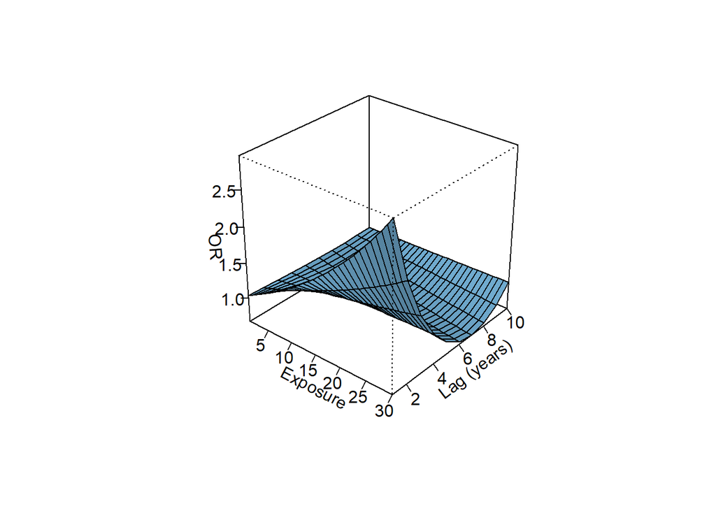

```r
# Predict
pred.lin.4 <- crosspred(
  cb.lin.4, # crossbasis
  clogit.lin.4, # model
  at = 1:30, # range values of PM2.5 to use for prediction select based on min/max pm2.5 concentrations in dataset
  bylag = 1, # lag increments
  cumul = TRUE, # estimate cumulative effect
  cen = 0) # references for estimate


## Visuals

# 3-D plot
plot(pred.lin.4, zlab="OR", xlab="Exposure", ylab="Lag (years)",
       theta=40, phi=30, lphi=30)
```

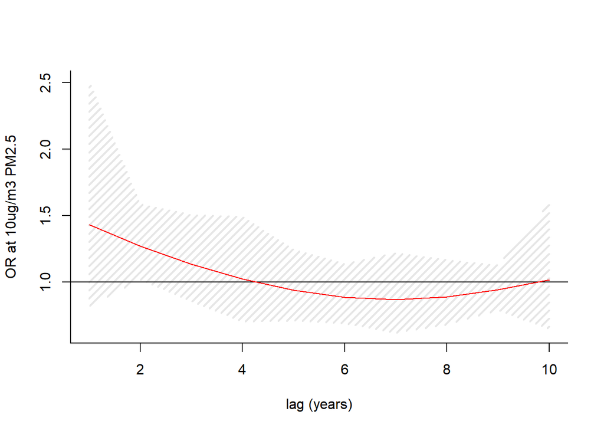

```r
# Plot lag exposure-response at exposure of 10ug/m3
plot(pred.lin.4,
     var = 10,
     col = "red",
     ci.arg = list(density = 15, lwd =2),
      ylab = "OR at 10ug/m3 PM2.5", xlab = "lag (years)")
```

```r
## Extract estimates per lag
# I created the OR_lag() and OR_cumm() function to extract the per lag and cummulative estimates and organize them into a dataset to use later for figures. The functions aare in  the functions_yanelli.R  file  in this folder
OR_4df <- OR_lag(pred.lin.4, "4-df")


## Extract cumulative estimates for 1, 5 and 10 lags

OR_cumm_4df <- OR_cumm(pred.lin.4, "4-df")
```

#### ii. Lag constrain with 3 df:

This model has a lower AIC relative to the model with a lag constrain of 4df. So we select this models as the model for the main analysis

```r
clogit.lin.3 <- survival::clogit(ck ~ cb.lin.3 +
                               family_SES +
                               place_birth +
                               civst +
                               residence +
                               strata(nr), method = "efron", data = lag_wide)

summary(clogit.lin.3)
```

```
## Call:
## coxph(formula = Surv(rep(1, 22065L), ck) ~ cb.lin.3 + family_SES +
##     place_birth + civst + residence + strata(nr), data = lag_wide,
##     method = "efron")
##
##   n= 22065, number of events= 3801
##
##                                  coef exp(coef)  se(coef)      z Pr(>|z|)
## cb.lin.3v1.l1               -0.040736  0.960082  0.032615 -1.249 0.211659
## cb.lin.3v1.l2                0.020316  1.020524  0.011204  1.813 0.069776 .
## cb.lin.3v1.l3               -0.019504  0.980685  0.017674 -1.104 0.269790
## family_SES2                 -0.105843  0.899566  0.073279 -1.444 0.148634
## family_SES3                 -0.092382  0.911757  0.067219 -1.374 0.169338
## family_SES4                 -0.219426  0.802979  0.063469 -3.457 0.000546 ***
## family_SES5                 -0.218610  0.803635  0.068632 -3.185 0.001446 **
## family_SES9                 -0.316193  0.728919  0.085542 -3.696 0.000219 ***
## place_birthforeign          -0.380013  0.683852  0.112231 -3.386 0.000709 ***
## place_birthgreenland         0.330499  1.391662  0.167688  1.971 0.048734 *
## place_birthother_cities      0.047389  1.048529  0.051037  0.929 0.353137
## place_birthother_dk          0.055906  1.057498  0.051431  1.087 0.277032
## place_birthunknown           0.012076  1.012149  0.242208  0.050 0.960235
## civst2                       0.028831  1.029251  0.081045  0.356 0.722036
## civst3                      -0.072887  0.929706  0.083280 -0.875 0.381461
## civst4                      -0.002762  0.997241  0.068147 -0.041 0.967667
## residenceGreater Copenhagen  0.092855  1.097303  0.073426  1.265 0.206010
## residenceRest of Denmark    -0.009037  0.991004  0.038341 -0.236 0.813675
## residenceUnknown            -0.298555  0.741890  0.481739 -0.620 0.535427
## ---
## Signif. codes:  0 '***' 0.001 '**' 0.01 '*' 0.05 '.' 0.1 ' ' 1
##
##                             exp(coef) exp(-coef) lower .95 upper .95
## cb.lin.3v1.l1                  0.9601     1.0416    0.9006    1.0235
## cb.lin.3v1.l2                  1.0205     0.9799    0.9984    1.0432
## cb.lin.3v1.l3                  0.9807     1.0197    0.9473    1.0153
## family_SES2                    0.8996     1.1116    0.7792    1.0385
## family_SES3                    0.9118     1.0968    0.7992    1.0402
## family_SES4                    0.8030     1.2454    0.7091    0.9093
## family_SES5                    0.8036     1.2443    0.7025    0.9193
## family_SES9                    0.7289     1.3719    0.6164    0.8620
## place_birthforeign             0.6839     1.4623    0.5488    0.8521
## place_birthgreenland           1.3917     0.7186    1.0018    1.9332
## place_birthother_cities        1.0485     0.9537    0.9487    1.1588
## place_birthother_dk            1.0575     0.9456    0.9561    1.1697
## place_birthunknown             1.0121     0.9880    0.6296    1.6271
## civst2                         1.0293     0.9716    0.8781    1.2064
## civst3                         0.9297     1.0756    0.7897    1.0945
## civst4                         0.9972     1.0028    0.8726    1.1397
## residenceGreater Copenhagen    1.0973     0.9113    0.9502    1.2671
## residenceRest of Denmark       0.9910     1.0091    0.9193    1.0683
## residenceUnknown               0.7419     1.3479    0.2886    1.9072
##
## Concordance= 0.531  (se = 0.007 )
## Likelihood ratio test= 57.48  on 19 df,   p=1e-05
## Wald test            = 55.78  on 19 df,   p=2e-05
## Score (logrank) test = 56.28  on 19 df,   p=1e-05
```

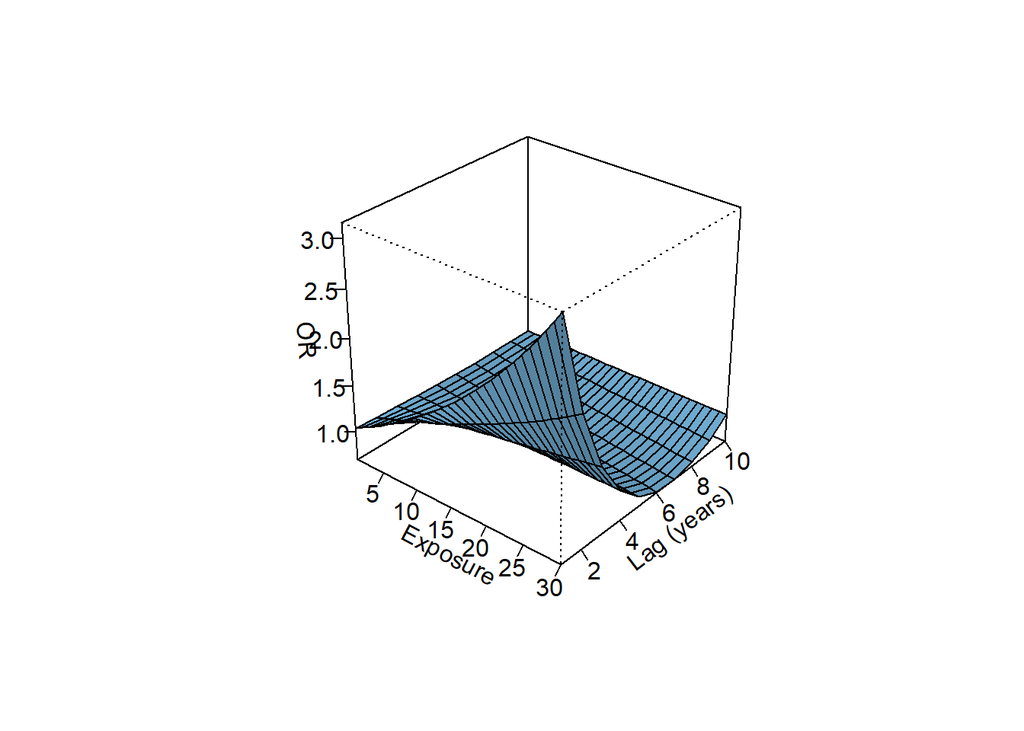

```r
# Predict

pred.lin.3 <- crosspred(
  cb.lin.3, # crossbasis
  clogit.lin.3, # model
  at = 1:30, # range values of PM2.5 to use for prediction
  bylag = 1, # lag increments
  cumul = TRUE, # estimate cumulative effect at each lag
  cen = 0) # references for nonlinear associations


# Visuals

# 3-D plot
plot(pred.lin.3, zlab="OR", xlab="Exposure", ylab="Lag (years)",
       theta=40, phi=30, lphi=30)
```

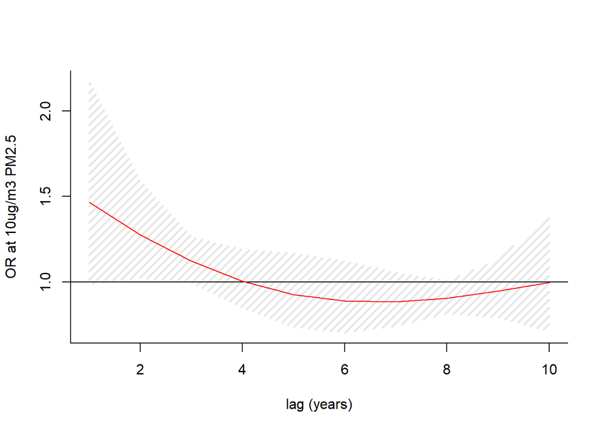

```r
# Plot lag exposure-response at exposure of 10ug/m3

plot(pred.lin.3,
     var = 10,
     col = "red",
     ci.arg = list(density = 15, lwd =2),
      ylab = "OR at 10ug/m3 PM2.5", xlab = "lag (years)")
```

```r
## Extract estimates per lag

OR_3df <- OR_lag(pred.lin.3, "3-df")

## Extract cumulative estimates at each lag

OR_cumm_3df <- OR_cumm(pred.lin.3, "3-df")
```

### 5b. Compare models’ AIC values

- Compare the AIC values for the 3-df and 4-df lag constraint models
- The model with the 3df constrain has a better fit based on AIC

```r
aictab(cand.set = list(clogit.lin.3, clogit.lin.4), modnames = c('3df-constraint', '4df-constraint'))
```

```
##
## Model selection based on AICc:
##
##                 K     AICc Delta_AICc AICcWt Cum.Wt       LL
## 3df-constraint 19 13324.49          0   0.73   0.73 -6643.23
## 4df-constraint 20 13326.49          2   0.27   1.00 -6643.23
```

### 5c. Lag constrain with 3 df adjusted for parish SES

The model with a lag constrain with 3df has the lowest AIC so here I’m running the model again but adjusted for parish SES

```r
clogit.lin.ses <- survival::clogit(ck ~ cb.lin.3 +
                               family_SES +
                               place_birth +
                               civst +
                               residence +
                               parish_ses +
                               strata(nr), method = "efron", data = lag_wide)

summary(clogit.lin.ses)
```

```
## Call:
## coxph(formula = Surv(rep(1, 22065L), ck) ~ cb.lin.3 + family_SES +
##     place_birth + civst + residence + parish_ses + strata(nr),
##     data = lag_wide, method = "efron")
##
##   n= 21297, number of events= 3652
##    (768 observations deleted due to missingness)
##
##                                  coef exp(coef)  se(coef)      z Pr(>|z|)
## cb.lin.3v1.l1               -0.048808  0.952363  0.033959 -1.437  0.15064
## cb.lin.3v1.l2                0.020552  1.020765  0.011765  1.747  0.08065 .
## cb.lin.3v1.l3               -0.014423  0.985680  0.018399 -0.784  0.43310
## family_SES2                 -0.097337  0.907250  0.075156 -1.295  0.19527
## family_SES3                 -0.083010  0.920342  0.069323 -1.197  0.23113
## family_SES4                 -0.199780  0.818911  0.065510 -3.050  0.00229 **
## family_SES5                 -0.219099  0.803242  0.071464 -3.066  0.00217 **
## family_SES9                 -0.351901  0.703350  0.088945 -3.956 7.61e-05 ***
## place_birthforeign          -0.346308  0.707294  0.116019 -2.985  0.00284 **
## place_birthgreenland         0.345898  1.413258  0.171971  2.011  0.04429 *
## place_birthother_cities      0.054173  1.055667  0.052571  1.030  0.30279
## place_birthother_dk          0.076751  1.079774  0.053235  1.442  0.14937
## place_birthunknown          -0.007346  0.992681  0.248851 -0.030  0.97645
## civst2                       0.003660  1.003667  0.082799  0.044  0.96474
## civst3                      -0.102561  0.902523  0.085482 -1.200  0.23022
## civst4                      -0.020580  0.979630  0.069520 -0.296  0.76720
## residenceGreater Copenhagen  0.106694  1.112594  0.078306  1.363  0.17303
## residenceRest of Denmark    -0.007560  0.992468  0.039205 -0.193  0.84708
## residenceUnknown            -0.999309  0.368134  0.736693 -1.356  0.17495
## parish_ses                   0.002862  1.002866  0.002696  1.062  0.28837
## ---
## Signif. codes:  0 '***' 0.001 '**' 0.01 '*' 0.05 '.' 0.1 ' ' 1
##
##                             exp(coef) exp(-coef) lower .95 upper .95
## cb.lin.3v1.l1                  0.9524     1.0500   0.89104    1.0179
## cb.lin.3v1.l2                  1.0208     0.9797   0.99750    1.0446
## cb.lin.3v1.l3                  0.9857     1.0145   0.95077    1.0219
## family_SES2                    0.9073     1.1022   0.78299    1.0512
## family_SES3                    0.9203     1.0866   0.80342    1.0543
## family_SES4                    0.8189     1.2211   0.72024    0.9311
## family_SES5                    0.8032     1.2450   0.69826    0.9240
## family_SES9                    0.7034     1.4218   0.59083    0.8373
## place_birthforeign             0.7073     1.4138   0.56344    0.8879
## place_birthgreenland           1.4133     0.7076   1.00888    1.9797
## place_birthother_cities        1.0557     0.9473   0.95231    1.1702
## place_birthother_dk            1.0798     0.9261   0.97279    1.1985
## place_birthunknown             0.9927     1.0074   0.60952    1.6167
## civst2                         1.0037     0.9963   0.85332    1.1805
## civst3                         0.9025     1.1080   0.76330    1.0671
## civst4                         0.9796     1.0208   0.85484    1.1226
## residenceGreater Copenhagen    1.1126     0.8988   0.95430    1.2972
## residenceRest of Denmark       0.9925     1.0076   0.91906    1.0717
## residenceUnknown               0.3681     2.7164   0.08688    1.5598
## parish_ses                     1.0029     0.9971   0.99758    1.0082
##
## Concordance= 0.53  (se = 0.007 )
## Likelihood ratio test= 61.75  on 20 df,   p=4e-06
## Wald test            = 59.26  on 20 df,   p=9e-06
## Score (logrank) test = 59.96  on 20 df,   p=7e-06
```

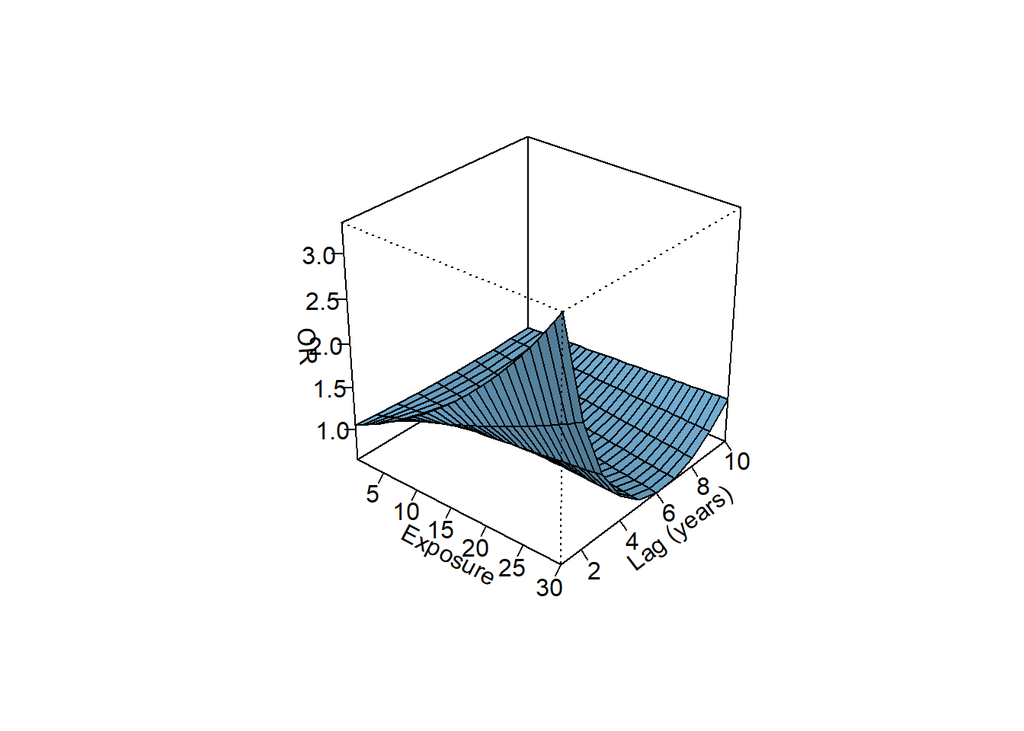

```r
# Predict

pred.lin.ses <- crosspred(
  cb.lin.3, # crossbasis
  clogit.lin.ses, # model
  at = 1:30, # range values of PM2.5 to use for prediction
  bylag = 1, # lag increments
  cumul = TRUE, # estimate cumulative effect at each lag
  cen = 0) # references for nonlinear associations


# Visuals

# 3-D plot
plot(pred.lin.ses, zlab="OR", xlab="Exposure", ylab="Lag (years)",
       theta=40, phi=30, lphi=30)
```

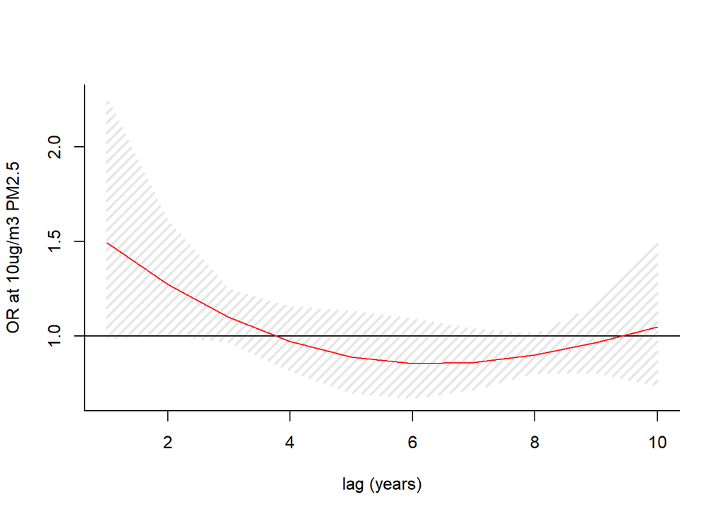

```r
# Plot lag exposure-response at exposure of 10ug/m3

plot(pred.lin.ses,
     var = 10,
     col = "red",
     ci.arg = list(density = 15, lwd =2),
      ylab = "OR at 10ug/m3 PM2.5", xlab = "lag (years)")
```

```r
## Extract estimates per lag

OR_3df_ses <- OR_lag(pred.lin.ses, "3-df w/parish ses")


## Extract cumulative estimates at each lag

OR_cumm_3df_ses <- OR_cumm(pred.lin.ses, "3-df with/parish ses")
```

## 6. Compile and save effect estimates

- I combined the effect estimates from the three models (4df and 3df lag constrain, and 3df lag constrained adjusted for parish SES ) into a single dataset both for the single lag effect estimates and the cumulative effect estimates. I saved the dataset as a .csv into file in the output folder

```r
# by lag effect estimates

per_lag_effects <- rbind(OR_3df, OR_4df) %>%
  rbind(., OR_3df_ses)

knitr::kable(per_lag_effects)
```

| lag | OR | lower_CI | upper_CI | lag_constr |
| --- | --- | --- | --- | --- |
| lag1 | 1.0389989 | 0.9986803 | 1.080945 | 3-df |
| lag2 | 1.0246795 | 1.0022280 | 1.047634 | 3-df |
| lag3 | 1.0115315 | 0.9994435 | 1.023766 | 3-df |
| lag4 | 1.0004782 | 0.9837421 | 1.017499 | 3-df |
| lag5 | 0.9924100 | 0.9697382 | 1.015612 | 3-df |
| lag6 | 0.9881682 | 0.9652206 | 1.011661 | 3-df |
| lag7 | 0.9877042 | 0.9703831 | 1.005335 | 3-df |
| lag8 | 0.9900980 | 0.9794433 | 1.000869 | 3-df |
| lag9 | 0.9944119 | 0.9768518 | 1.012288 | 3-df |
| lag10 | 0.9997073 | 0.9663644 | 1.034201 | 3-df |
| lag1 | 1.0366712 | 0.9799351 | 1.096692 | 4-df |
| lag2 | 1.0243882 | 1.0019680 | 1.047310 | 4-df |
| lag3 | 1.0127905 | 0.9845816 | 1.041808 | 4-df |
| lag4 | 1.0023927 | 0.9653523 | 1.040854 | 4-df |
| lag5 | 0.9937883 | 0.9661757 | 1.022190 | 4-df |
| lag6 | 0.9879480 | 0.9634668 | 1.013051 | 4-df |
| lag7 | 0.9859342 | 0.9529888 | 1.020018 | 4-df |
| lag8 | 0.9883780 | 0.9619245 | 1.015559 | 4-df |
| lag9 | 0.9941232 | 0.9765444 | 1.012018 | 4-df |
| lag10 | 1.0015634 | 0.9575038 | 1.047650 | 4-df |
| lag1 | 1.0408824 | 0.9983722 | 1.085203 | 3-df w/parish ses |
| lag2 | 1.0243723 | 1.0005848 | 1.048725 | 3-df w/parish ses |
| lag3 | 1.0093439 | 0.9966095 | 1.022241 | 3-df w/parish ses |
| lag4 | 0.9969440 | 0.9797116 | 1.014480 | 3-df w/parish ses |
| lag5 | 0.9882751 | 0.9649088 | 1.012207 | 3-df w/parish ses |
| lag6 | 0.9843819 | 0.9606425 | 1.008708 | 3-df w/parish ses |
| lag7 | 0.9852085 | 0.9671518 | 1.003602 | 3-df w/parish ses |
| lag8 | 0.9896191 | 0.9783655 | 1.001002 | 3-df w/parish ses |
| lag9 | 0.9964564 | 0.9782486 | 1.015003 | 3-df w/parish ses |
| lag10 | 1.0045550 | 0.9700155 | 1.040324 | 3-df w/parish ses |

```r
# write_csv(per_lag_effects, paste0(output.folder, "distributed_lags_OR.csv"))

# cumulative estimates

cumm_effects <- rbind(OR_cumm_3df, OR_cumm_4df) %>%
  rbind(., OR_cumm_3df_ses)

knitr::kable(cumm_effects)
```

| lag | OR_cumm | lower_CI | upper_CI | lag_constr |
| --- | --- | --- | --- | --- |
| lag1 | 1.038999 | 0.9986803 | 1.080945 | 3-df |
| lag2 | 1.064641 | 1.0014408 | 1.131830 | 3-df |
| lag3 | 1.076918 | 1.0063892 | 1.152389 | 3-df |
| lag4 | 1.077433 | 1.0098667 | 1.149520 | 3-df |
| lag5 | 1.069255 | 1.0066005 | 1.135810 | 3-df |
| lag6 | 1.056604 | 0.9943794 | 1.122722 | 3-df |
| lag7 | 1.043612 | 0.9801908 | 1.111137 | 3-df |
| lag8 | 1.033278 | 0.9743707 | 1.095747 | 3-df |
| lag9 | 1.027504 | 0.9831292 | 1.073882 | 3-df |
| lag10 | 1.027203 | 0.9976042 | 1.057681 | 3-df |
| lag1 | 1.036671 | 0.9799351 | 1.096692 | 4-df |
| lag2 | 1.061954 | 0.9859388 | 1.143829 | 4-df |
| lag3 | 1.075537 | 1.0033458 | 1.152922 | 4-df |
| lag4 | 1.078110 | 1.0084571 | 1.152574 | 4-df |
| lag5 | 1.071413 | 0.9995620 | 1.148429 | 4-df |
| lag6 | 1.058501 | 0.9917447 | 1.129750 | 4-df |
| lag7 | 1.043612 | 0.9801871 | 1.111141 | 4-df |
| lag8 | 1.031483 | 0.9657609 | 1.101678 | 4-df |
| lag9 | 1.025421 | 0.9708401 | 1.083071 | 4-df |
| lag10 | 1.027024 | 0.9972827 | 1.057653 | 4-df |
| lag1 | 1.040882 | 0.9983722 | 1.085203 | 3-df with/parish ses |
| lag2 | 1.066251 | 0.9995031 | 1.137457 | 3-df with/parish ses |
| lag3 | 1.076214 | 1.0016427 | 1.156337 | 3-df with/parish ses |
| lag4 | 1.072925 | 1.0014907 | 1.149455 | 3-df with/parish ses |
| lag5 | 1.060345 | 0.9944310 | 1.130628 | 3-df with/parish ses |
| lag6 | 1.043785 | 0.9790721 | 1.112774 | 3-df with/parish ses |
| lag7 | 1.028345 | 0.9630274 | 1.098094 | 3-df with/parish ses |
| lag8 | 1.017670 | 0.9571656 | 1.082000 | 3-df with/parish ses |
| lag9 | 1.014064 | 0.9681657 | 1.062139 | 3-df with/parish ses |
| lag10 | 1.018683 | 0.9874719 | 1.050881 | 3-df with/parish ses |

```r
# write_csv(cumm_effects, paste0(output.folder, "cumm_lags_OR.csv"))
```